# Suma de la Generacion TG1 + TG2

Notas:

## Seteo Inicial

```python
# -*- coding: utf-8 -*-
"""
Created on Viernes 8 Octubre 2021 17:43:11

@author: Daniel Busso
"""

# Plantilla de Pre Procesado

# Cómo importar las librerías
import numpy    as np
import pandas   as pd
import datetime as dt
import os

# Gráficos
# ==============================================================================
import matplotlib.pyplot as plt
import seaborn as sns
%matplotlib inline
plt.style.use('fivethirtyeight')

#from statsmodels.graphics.tsaplots import plot_acf
#from statsmodels.graphics.tsaplots import plot_pacf


# Configuración warnings
# ==============================================================================
import warnings
warnings.filterwarnings('ignore')
```

```python
# Modelado y Forecasting
# ==============================================================================
from sklearn.linear_model import LinearRegression
from sklearn.linear_model import Lasso
from sklearn.linear_model import Ridge
from sklearn.ensemble import RandomForestRegressor
#from xgboost import XGBRegressor

from sklearn.metrics import mean_squared_error
from sklearn.metrics import mean_absolute_error
#from sklearn.metrics import mean_absolute_percentage_error

#from skforecast.ForecasterAutoreg import ForecasterAutoreg
#from skforecast.ForecasterAutoregMultiOutput import ForecasterAutoregMultiOutput
#from skforecast.model_selection import grid_search_forecaster
#from skforecast.model_selection import time_series_spliter
#from skforecast.model_selection import cv_forecaster
#from skforecast.model_selection import backtesting_forecaster
#from skforecast.model_selection import backtesting_forecaster_intervals
```

```python
# Configuracion Pandas

pd.set_option('display.max_rows', 200)
pd.set_option('display.max_columns', None)
pd.set_option('display.width', None)
pd.set_option('display.max_colwidth', -1)
pd.set_option('display.float_format', '{:.2f}'.format)
```

```python
def conversion_2400(fecha):
    if fecha[11:13] != '24':
        return pd.to_datetime(fecha, format='%d/%m/%Y %H:%M')

    fecha = fecha[0:11] + '00:' + fecha[14:]
    return pd.to_datetime(fecha, format='%d/%m/%Y %H:%M') + dt.timedelta(days=1)
```

## TG1

```python
# EMPIEZO PROCESANDO UNA CARPETA
# AUTOMATIZAR LECTURAS DE VARIOS ARCHIVOS .PRN ANUALES
# lEER Y CONCATENAR LOS ARCHIVOS .prn DE LA CARPETA DSPractica/eetts/sanfrancisco/TD1

import os
import sys
from pathlib import Path

# ELEGIR PLATAFORMA WINDOWS LOCAL O GOOGLE COLABORATORY
if sys.platform == 'linux' :
  from google.colab import drive
  drive.mount('/content/drive', force_remount=True)
  carpeta_trabajo = Path('/content/drive/Othercomputers/LENOVO/eett_prod/san_francisco/TG1') # Google Colab
else:
  carpeta_inicio  = Path.home()
  carpeta_eett = Path("eett_prod/san_francisco/TG1")
  carpeta_trabajo = carpeta_inicio / carpeta_eett

archivos = list(carpeta_trabajo.glob('*.prn'))

# Automatizacion de los DataFrames
dfconca = pd.DataFrame([])
for nombre_completo in archivos:
    dfdatos = pd.read_fwf(nombre_completo, header=0, decimal=',')
    dfconca = pd.concat([dfconca, dfdatos], ignore_index=True)

# BORRAMOS COLUMNAS NO USADAS (LA TENSION ESTA SIEMPRE EN CERO)
dfconca = dfconca.drop(columns=['Ampere', 'KVolt'])
dfconca
```

|  | Fecha | Hora | MW | MVAR | MVA |
| --- | --- | --- | --- | --- | --- |
| 0 | 01/01/2011 | 00:15 | 11.22 | 2.39 | 11.47 |
| 1 | 01/01/2011 | 00:30 | 0.00 | 0.06 | 0.06 |
| 2 | 01/01/2011 | 00:45 | 0.00 | 0.07 | 0.07 |
| 3 | 01/01/2011 | 01:00 | 0.00 | 0.07 | 0.07 |
| 4 | 01/01/2011 | 01:15 | 0.00 | 0.07 | 0.07 |
| ... | ... | ... | ... | ... | ... |
| 736115 | 31/12/2021 | 23:40 | 0.00 | 0.08 | 0.08 |
| 736116 | 31/12/2021 | 23:45 | 0.00 | 0.08 | 0.08 |
| 736117 | 31/12/2021 | 23:50 | 0.00 | 0.08 | 0.08 |
| 736118 | 31/12/2021 | 23:55 | 0.00 | 0.08 | 0.08 |
| 736119 | 31/12/2021 | 24:00 | 0.00 | 0.08 | 0.08 |

736120 rows × 5 columns

```python
archivos
```

```
[WindowsPath('C:/Users/debus/eett_prod/san_francisco/TG1/MED_SANFCO_13_TG1_2011_1240.prn'),
 WindowsPath('C:/Users/debus/eett_prod/san_francisco/TG1/MED_SANFCO_13_TG1_2012_1240.prn'),
 WindowsPath('C:/Users/debus/eett_prod/san_francisco/TG1/MED_SANFCO_13_TG1_2013_1239.prn'),
 WindowsPath('C:/Users/debus/eett_prod/san_francisco/TG1/MED_SANFCO_13_TG1_2014_1238.prn'),
 WindowsPath('C:/Users/debus/eett_prod/san_francisco/TG1/MED_SANFCO_13_TG1_2015_0758.prn'),
 WindowsPath('C:/Users/debus/eett_prod/san_francisco/TG1/MED_SANFCO_13_TG1_2016_0757.prn'),
 WindowsPath('C:/Users/debus/eett_prod/san_francisco/TG1/MED_SANFCO_13_TG1_2017_0756.prn'),
 WindowsPath('C:/Users/debus/eett_prod/san_francisco/TG1/MED_SANFCO_13_TG1_2018_0755.prn'),
 WindowsPath('C:/Users/debus/eett_prod/san_francisco/TG1/MED_SANFCO_13_TG1_2019_0754.prn'),
 WindowsPath('C:/Users/debus/eett_prod/san_francisco/TG1/MED_SANFCO_13_TG1_2020_0752.prn'),
 WindowsPath('C:/Users/debus/eett_prod/san_francisco/TG1/MED_SANFCO_13_TG1_2021_1254.prn')]
```

```python
# GENERAMOS INDICE DE FECHAS PARA MANEJAR LA SERIE DE TIEMPO
# Lectura y creacion del index DateTime para tratar el DataFrame como una Serie de Tiempo

dfconca['Fecha_Hora'] = dfconca['Fecha'] + ' ' + dfconca['Hora']
dfconca['Fecha_Hora'] = dfconca.Fecha_Hora.apply(conversion_2400) # CONVERSION DE HORA 24:00 ---> 00:00

dfconca.set_index('Fecha_Hora', inplace=True)
serie     = dfconca.drop(dfconca.index[-1]) # borro la fila del nuevo anio
serie_ord = serie.sort_index()
TG1 = serie_ord.copy()

# BORRAMOS Columnas Fecha Hora porque ya tenemos el Index Temporal
TG1 = TG1.drop(columns=['Fecha', 'Hora'])

# Renombramos Columnas
TG1.columns = ['TG1_MW', 'TG1_MVAR', 'TG1_MVA']
#TG1.columns = ['TG1_MW', 'TG1_MVAR', 'TG1_MVA', 'TG1_Ampere', 'TG1_KVolt']

# VERIFICAR Y REMOVER DUPLICADOS

if TG1.index.has_duplicates:
    print('SI TIENE DUPLICADOS')
else:
    print('NO TIENE DUPLICADOS')

TG1
```

```
NO TIENE DUPLICADOS
```

| Fecha_Hora | TG1_MW | TG1_MVAR | TG1_MVA |
| --- | --- | --- | --- |
| 2011-01-01 00:15:00 | 11.22 | 2.39 | 11.47 |
| 2011-01-01 00:30:00 | 0.00 | 0.06 | 0.06 |
| 2011-01-01 00:45:00 | 0.00 | 0.07 | 0.07 |
| 2011-01-01 01:00:00 | 0.00 | 0.07 | 0.07 |
| 2011-01-01 01:15:00 | 0.00 | 0.07 | 0.07 |
| ... | ... | ... | ... |
| 2021-12-31 23:35:00 | 0.00 | 0.08 | 0.08 |
| 2021-12-31 23:40:00 | 0.00 | 0.08 | 0.08 |
| 2021-12-31 23:45:00 | 0.00 | 0.08 | 0.08 |
| 2021-12-31 23:50:00 | 0.00 | 0.08 | 0.08 |
| 2021-12-31 23:55:00 | 0.00 | 0.08 | 0.08 |

736119 rows × 3 columns

```python
TG1[TG1['TG1_MW'] > 1.0]
```

| Fecha_Hora | TG1_MW | TG1_MVAR | TG1_MVA |
| --- | --- | --- | --- |
| 2011-01-01 00:15:00 | 11.22 | 2.39 | 11.47 |
| 2011-01-01 13:30:00 | 10.65 | 1.87 | 10.81 |
| 2011-01-01 13:45:00 | 10.63 | 1.31 | 10.71 |
| 2011-01-01 14:00:00 | 10.57 | 1.04 | 10.62 |
| 2011-01-01 14:15:00 | 10.42 | 1.04 | 10.47 |
| ... | ... | ... | ... |
| 2021-12-30 21:50:00 | 8.72 | 1.76 | 8.89 |
| 2021-12-30 21:55:00 | 8.75 | 1.74 | 8.92 |
| 2021-12-30 22:00:00 | 8.75 | 1.79 | 8.93 |
| 2021-12-30 22:05:00 | 8.85 | 1.89 | 9.05 |
| 2021-12-30 22:10:00 | 3.11 | 0.84 | 3.22 |

40538 rows × 3 columns

```python
TG1['TG1_MW'] > 1.00
```

```
Fecha_Hora
2011-01-01 00:15:00    True
2011-01-01 00:30:00    False
2011-01-01 00:45:00    False
2011-01-01 01:00:00    False
2011-01-01 01:15:00    False
                       ...
2021-12-31 23:35:00    False
2021-12-31 23:40:00    False
2021-12-31 23:45:00    False
2021-12-31 23:50:00    False
2021-12-31 23:55:00    False
Name: TG1_MW, Length: 736119, dtype: bool
```

### TG1 Remover Atipicos

```python
# CALCULO FORMAL DE LOS LIMITES SUPERIOR E INFERIOR

Pot_Instalada = pd.Series([20.0, 28.0], index=['TG1', 'TG2'])  # con cos fi = 0.8 TG1 = 16 MW y TG2 = 23 MW
POT_INSTALADA = Pot_Instalada.sum()

q75, q25 = TG1['TG1_MVA'].quantile(0.75), TG1['TG1_MVA'].quantile(0.25)
IQR = q75 - q25
bigote = 3 * IQR
lim_sup, lim_inf = q75 + bigote, q25 - bigote
if lim_inf < 0 :
    lim_inf = 0.0


# PODRIA USAR DIRECTAMENTE COMO LIMITES
lim_sup = Pot_Instalada.TG1
lim_inf = 0
```

```python
# IDENTIFICAR ATIPICOS
TG1_atipicos = TG1[(TG1['TG1_MVA'] < lim_inf) | (TG1['TG1_MVA'] > lim_sup)]
print('Atipicos identificados: %d' % len(TG1_atipicos))

# REMOVER ATIPICOS
TG1_sin_atipicos = TG1[(TG1['TG1_MVA'] >= lim_inf) & (TG1['TG1_MVA'] <= lim_sup)]
print('TG1_MVA sin Atipicos: %d' % len(TG1_sin_atipicos))
```

```
Atipicos identificados: 25
TG1_MVA sin Atipicos: 736094
```

```python
TG1_sin_atipicos
```

| Fecha_Hora | TG1_MW | TG1_MVAR | TG1_MVA |
| --- | --- | --- | --- |
| 2011-01-01 00:15:00 | 11.22 | 2.39 | 11.47 |
| 2011-01-01 00:30:00 | 0.00 | 0.06 | 0.06 |
| 2011-01-01 00:45:00 | 0.00 | 0.07 | 0.07 |
| 2011-01-01 01:00:00 | 0.00 | 0.07 | 0.07 |
| 2011-01-01 01:15:00 | 0.00 | 0.07 | 0.07 |
| ... | ... | ... | ... |
| 2021-12-31 23:35:00 | 0.00 | 0.08 | 0.08 |
| 2021-12-31 23:40:00 | 0.00 | 0.08 | 0.08 |
| 2021-12-31 23:45:00 | 0.00 | 0.08 | 0.08 |
| 2021-12-31 23:50:00 | 0.00 | 0.08 | 0.08 |
| 2021-12-31 23:55:00 | 0.00 | 0.08 | 0.08 |

736094 rows × 3 columns

```python
TG1_sin_atipicos.info()
```

```
<class 'pandas.core.frame.DataFrame'>
DatetimeIndex: 736094 entries, 2011-01-01 00:15:00 to 2021-12-31 23:55:00
Data columns (total 3 columns):
 #   Column    Non-Null Count   Dtype
---  ------    --------------   -----
 0   TG1_MW    736094 non-null  float64
 1   TG1_MVAR  736094 non-null  float64
 2   TG1_MVA   736094 non-null  float64
dtypes: float64(3)
memory usage: 22.5 MB
```

### NOTA:

No conviene Interpolar las Filas Faltantes (que no es lo mismo que la fila con valores nap) Las Filas faltantes pueden ser: .- Las que faltan del SITEC .- Las Removidas por ser Valores Atipicos Porque en el caso de los Generadores puede ampliar o cambiar el Tiemp Real de Generacion. Ademas hay mucha data, muchas filas / observaciones

## TG2

```python
# EMPIEZO PROCESANDO UNA CARPETA
# AUTOMATIZAR LECTURAS DE VARIOS ARCHIVOS .PRN ANUALES
# lEER Y CONCATENAR LOS ARCHIVOS .prn DE LA CARPETA DSPractica/eetts/sanfrancisco/TG2

import os
import sys
from pathlib import Path

# ELEGIR PLATAFORMA WINDOWS LOCAL O GOOGLE COLABORATORY
if sys.platform == 'linux' :
  from google.colab import drive
  drive.mount('/content/drive', force_remount=True)
  carpeta_trabajo = Path('/content/drive/Othercomputers/LENOVO/eett_prod/san_francisco/TG2') # Google Colab
else:
  carpeta_inicio  = Path.home()
  carpeta_eett = Path("eett_prod/san_francisco/TG2")
  carpeta_trabajo = carpeta_inicio / carpeta_eett

archivos = list(carpeta_trabajo.glob('*.prn'))

# Automatizacion de los DataFrames
dfconca = pd.DataFrame([])
for nombre_completo in archivos:
    dfdatos = pd.read_fwf(nombre_completo, header=0, decimal=',')
    dfconca = pd.concat([dfconca, dfdatos], ignore_index=True)

# BORRAMOS COLUMNAS NO USADAS
dfconca = dfconca.drop(columns=['Ampere', 'KVolt'])
dfconca
```

|  | Fecha | Hora | MW | MVAR | MVA |
| --- | --- | --- | --- | --- | --- |
| 0 | 01/01/2011 | 00:15 | 0.00 | 0.06 | 0.06 |
| 1 | 01/01/2011 | 00:30 | 0.00 | 0.06 | 0.06 |
| 2 | 01/01/2011 | 00:45 | 0.00 | 0.06 | 0.06 |
| 3 | 01/01/2011 | 01:00 | 0.00 | 0.06 | 0.06 |
| 4 | 01/01/2011 | 01:15 | 0.00 | 0.06 | 0.06 |
| ... | ... | ... | ... | ... | ... |
| 736123 | 31/12/2021 | 23:40 | 0.00 | 0.08 | 0.08 |
| 736124 | 31/12/2021 | 23:45 | 0.00 | 0.08 | 0.08 |
| 736125 | 31/12/2021 | 23:50 | 0.00 | 0.08 | 0.08 |
| 736126 | 31/12/2021 | 23:55 | 0.00 | 0.09 | 0.09 |
| 736127 | 31/12/2021 | 24:00 | 0.00 | 0.08 | 0.08 |

736128 rows × 5 columns

```python
# GENERAMOS INDICE DE FECHAS PARA MANEJAR LA SERIE DE TIEMPO
# Lectura y creacion del index DateTime para tratar el DataFrame como una Serie de Tiempo

dfconca['Fecha_Hora'] = dfconca['Fecha'] + ' ' + dfconca['Hora']
dfconca['Fecha_Hora'] = dfconca.Fecha_Hora.apply(conversion_2400) # CONVERSION DE HORA 24:00 ---> 00:00

dfconca.set_index('Fecha_Hora', inplace=True)
serie     = dfconca.drop(dfconca.index[-1]) # borro la fila del nuevo anio
serie_ord = serie.sort_index()
TG2 = serie_ord.copy()

# BORRAMOS Columnas Fecha Hora porque ya tenemos el Index Temporal
TG2 = TG2.drop(columns=['Fecha', 'Hora'])

# Renombramos Columnas
TG2.columns = ['TG2_MW', 'TG2_MVAR', 'TG2_MVA']

# VERIFICAR Y REMOVER DUPLICADOS

if TG2.index.has_duplicates:
    print('SI TIENE DUPLICADOS')
else:
    print('NO TIENE DUPLICADOS')

TG2
```

```
NO TIENE DUPLICADOS
```

| Fecha_Hora | TG2_MW | TG2_MVAR | TG2_MVA |
| --- | --- | --- | --- |
| 2011-01-01 00:15:00 | 0.00 | 0.06 | 0.06 |
| 2011-01-01 00:30:00 | 0.00 | 0.06 | 0.06 |
| 2011-01-01 00:45:00 | 0.00 | 0.06 | 0.06 |
| 2011-01-01 01:00:00 | 0.00 | 0.06 | 0.06 |
| 2011-01-01 01:15:00 | 0.00 | 0.06 | 0.06 |
| ... | ... | ... | ... |
| 2021-12-31 23:35:00 | 0.00 | 0.08 | 0.08 |
| 2021-12-31 23:40:00 | 0.00 | 0.08 | 0.08 |
| 2021-12-31 23:45:00 | 0.00 | 0.08 | 0.08 |
| 2021-12-31 23:50:00 | 0.00 | 0.08 | 0.08 |
| 2021-12-31 23:55:00 | 0.00 | 0.09 | 0.09 |

736127 rows × 3 columns

### TG2 Remover Atipicos

```python
# CALCULO FORMAL DE LOS LIMITES SUPERIOR E INFERIOR

q75, q25 = TG2['TG2_MVA'].quantile(0.75), TG2['TG2_MVA'].quantile(0.25)
IQR = q75 - q25
bigote = 3 * IQR
lim_sup, lim_inf = q75 + bigote, q25 - bigote
if lim_inf < 0 :
    lim_inf = 0.0


# PODRIA USAR DIRECTAMENTE COMO LIMITES
lim_sup = Pot_Instalada.TG2
lim_inf = 0
```

```python
# IDENTIFICAR ATIPICOS
TG2_atipicos = TG2[(TG2['TG2_MVA'] < lim_inf) | (TG2['TG2_MVA'] > lim_sup)]
print('Atipicos identificados: %d' % len(TG2_atipicos))


# REMOVER ATIPICOS
TG2_sin_atipicos = TG2[(TG2['TG2_MVA'] >= lim_inf) & (TG2['TG2_MVA'] <= lim_sup)]
print('TG2_MVA sin Atipicos: %d' % len(TG2_sin_atipicos))
```

```
Atipicos identificados: 27
TG2_MVA sin Atipicos: 736100
```

```python
TG2_sin_atipicos
```

| Fecha_Hora | TG2_MW | TG2_MVAR | TG2_MVA |
| --- | --- | --- | --- |
| 2011-01-01 00:15:00 | 0.00 | 0.06 | 0.06 |
| 2011-01-01 00:30:00 | 0.00 | 0.06 | 0.06 |
| 2011-01-01 00:45:00 | 0.00 | 0.06 | 0.06 |
| 2011-01-01 01:00:00 | 0.00 | 0.06 | 0.06 |
| 2011-01-01 01:15:00 | 0.00 | 0.06 | 0.06 |
| ... | ... | ... | ... |
| 2021-12-31 23:35:00 | 0.00 | 0.08 | 0.08 |
| 2021-12-31 23:40:00 | 0.00 | 0.08 | 0.08 |
| 2021-12-31 23:45:00 | 0.00 | 0.08 | 0.08 |
| 2021-12-31 23:50:00 | 0.00 | 0.08 | 0.08 |
| 2021-12-31 23:55:00 | 0.00 | 0.09 | 0.09 |

736100 rows × 3 columns

## Concatenar TG1 + TG2 para despues sumar

```python
# CONCATENAR TD1 + TD2 + TD3
#
Gene = pd.concat([TG1_sin_atipicos, TG2_sin_atipicos], axis = 1)

# Reemplazar np.nan con ceros
Gene = Gene.replace(np.nan,0)

# Suma Potencia Aparente
Gene['Suma'] = Gene['TG1_MVA'] + Gene['TG2_MVA']

Gene
```

| Fecha_Hora | TG1_MW | TG1_MVAR | TG1_MVA | TG2_MW | TG2_MVAR | TG2_MVA | Suma |
| --- | --- | --- | --- | --- | --- | --- | --- |
| 2011-01-01 00:15:00 | 11.22 | 2.39 | 11.47 | 0.00 | 0.06 | 0.06 | 11.53 |
| 2011-01-01 00:30:00 | 0.00 | 0.06 | 0.06 | 0.00 | 0.06 | 0.06 | 0.12 |
| 2011-01-01 00:45:00 | 0.00 | 0.07 | 0.07 | 0.00 | 0.06 | 0.06 | 0.13 |
| 2011-01-01 01:00:00 | 0.00 | 0.07 | 0.07 | 0.00 | 0.06 | 0.06 | 0.13 |
| 2011-01-01 01:15:00 | 0.00 | 0.07 | 0.07 | 0.00 | 0.06 | 0.06 | 0.13 |
| ... | ... | ... | ... | ... | ... | ... | ... |
| 2021-12-31 23:35:00 | 0.00 | 0.08 | 0.08 | 0.00 | 0.08 | 0.08 | 0.16 |
| 2021-12-31 23:40:00 | 0.00 | 0.08 | 0.08 | 0.00 | 0.08 | 0.08 | 0.16 |
| 2021-12-31 23:45:00 | 0.00 | 0.08 | 0.08 | 0.00 | 0.08 | 0.08 | 0.16 |
| 2021-12-31 23:50:00 | 0.00 | 0.08 | 0.08 | 0.00 | 0.08 | 0.08 | 0.16 |
| 2021-12-31 23:55:00 | 0.00 | 0.08 | 0.08 | 0.00 | 0.09 | 0.09 | 0.17 |

736161 rows × 7 columns

```python
Gene.loc['2020-12-10 15:00:00']
```

```
TG1_MW     0.33
TG1_MVAR   -2.73
TG1_MVA    0.69
TG2_MW     8.88
TG2_MVAR   2.40
TG2_MVA    9.03
Suma       9.72
Name: 2020-12-10 15:00:00, dtype: float64
```

## Graficas

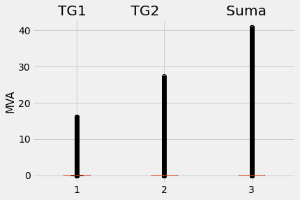

```python
#plt.boxplot(Trafos['TD1_MVA', 'TD2_MVA', 'TD3_MVA', 'Suma'])

data = Gene[['TG1_MVA', 'TG2_MVA', 'Suma']]
fig1, ax1 = plt.subplots()
ax1.set_title('TG1          TG2               Suma ')
ax1.set_ylabel("MVA", fontsize=15)  # Add a y-label to the axes.
ax1.boxplot(data)

plt.show()
```

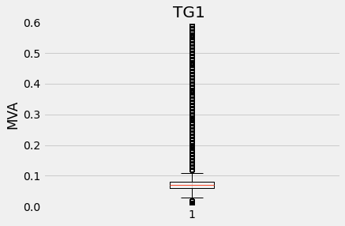

```python
#plt.boxplot(Trafos['TD1_MVA', 'TD2_MVA', 'TD3_MVA', 'Suma'])

data = Gene['TG1_MVA']
fig1, ax1 = plt.subplots()
ax1.set_title('TG1 ')
ax1.set_ylabel("MVA")  # Add a y-label to the axes.
ax1.set(ylim=(0, 0.6))
ax1.boxplot(data)

plt.show()
```

```python
Gene.describe()
```

|  | TG1_MW | TG1_MVAR | TG1_MVA | TG2_MW | TG2_MVAR | TG2_MVA | Suma |
| --- | --- | --- | --- | --- | --- | --- | --- |
| count | 736161.00 | 736161.00 | 736161.00 | 736161.00 | 736161.00 | 736161.00 | 736161.00 |
| mean | 0.43 | 0.29 | 0.53 | 1.12 | 0.68 | 1.26 | 1.79 |
| std | 1.98 | 1.19 | 2.12 | 3.56 | 2.31 | 4.10 | 5.28 |
| min | 0.00 | -9.78 | 0.00 | 0.00 | -9.95 | 0.00 | 0.00 |
| 25% | 0.00 | 0.06 | 0.06 | 0.00 | 0.07 | 0.07 | 0.14 |
| 50% | 0.00 | 0.07 | 0.07 | 0.00 | 0.08 | 0.08 | 0.15 |
| 75% | 0.00 | 0.08 | 0.08 | 0.00 | 0.08 | 0.08 | 0.16 |
| max | 14.67 | 39.60 | 16.11 | 22.20 | 59.40 | 27.22 | 40.86 |

```python
Pot_Instalada
```

```
TG1   20.00
TG2   28.00
dtype: float64
```

```
(0.0, 500.0)
```

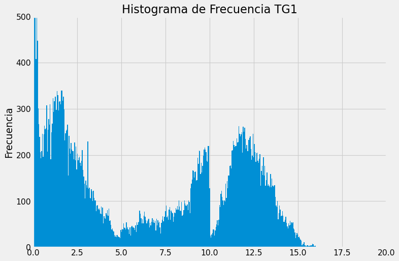

```python
TG1_MVA_median= Gene['TG1_MVA'].median()
TG1_MVA_median
plt.figure(figsize=(10,7), dpi= 80)
plt.hist(TG1['TG1_MVA'], bins=1000)
plt.gca().set(title='Histograma de Frecuencia TG1', ylabel='Frecuencia');
plt.xlim(0,20)
plt.ylim(0,500)
#plt.axvline(TG1_MVA_median, color='red')
```

```
(0.0, 600000.0)
```

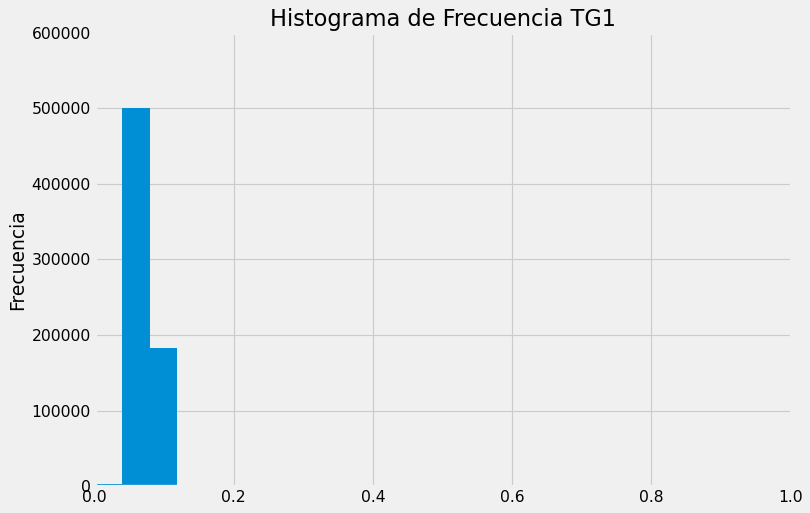

```python
contenedores =[0.0, 0.1, 0.2, 0.3, 0.4, 0.5, 0.6, 0.7, 0.8, 0.9, 1.0, 1.1, 1.2, 1.3, 1.4, 1.5, 1.6, 1.7, 1.8, 1.9, 2.0, 2.1, 2.2, 2.3, 2.4, 2.5]
TG1_MVA_median= Gene['TG1_MVA'].median()
TG1_MVA_median
plt.figure(figsize=(10,7), dpi= 80)
plt.hist(TG1['TG1_MVA'], bins=1000)
plt.gca().set(title='Histograma de Frecuencia TG1', ylabel='Frecuencia');
plt.xlim(0, 1.0)
plt.ylim(0,600000)
#plt.axvline(TG1_MVA_median, color='red')
```

```python
TG1[TG1['TG1_MVA'] <= 0.2]
```

| Fecha_Hora | TG1_MW | TG1_MVAR | TG1_MVA |
| --- | --- | --- | --- |
| 2011-01-01 00:30:00 | 0.00 | 0.06 | 0.06 |
| 2011-01-01 00:45:00 | 0.00 | 0.07 | 0.07 |
| 2011-01-01 01:00:00 | 0.00 | 0.07 | 0.07 |
| 2011-01-01 01:15:00 | 0.00 | 0.07 | 0.07 |
| 2011-01-01 01:30:00 | 0.00 | 0.06 | 0.06 |
| ... | ... | ... | ... |
| 2021-12-31 23:35:00 | 0.00 | 0.08 | 0.08 |
| 2021-12-31 23:40:00 | 0.00 | 0.08 | 0.08 |
| 2021-12-31 23:45:00 | 0.00 | 0.08 | 0.08 |
| 2021-12-31 23:50:00 | 0.00 | 0.08 | 0.08 |
| 2021-12-31 23:55:00 | 0.00 | 0.08 | 0.08 |

686500 rows × 3 columns

```python
TG1[TG1['TG1_MVA'] >= 5]
```

| Fecha_Hora | TG1_MW | TG1_MVAR | TG1_MVA |
| --- | --- | --- | --- |
| 2011-01-01 00:15:00 | 11.22 | 2.39 | 11.47 |
| 2011-01-01 13:30:00 | 10.65 | 1.87 | 10.81 |
| 2011-01-01 13:45:00 | 10.63 | 1.31 | 10.71 |
| 2011-01-01 14:00:00 | 10.57 | 1.04 | 10.62 |
| 2011-01-01 14:15:00 | 10.42 | 1.04 | 10.47 |
| ... | ... | ... | ... |
| 2021-12-30 21:45:00 | 8.74 | 1.73 | 8.91 |
| 2021-12-30 21:50:00 | 8.72 | 1.76 | 8.89 |
| 2021-12-30 21:55:00 | 8.75 | 1.74 | 8.92 |
| 2021-12-30 22:00:00 | 8.75 | 1.79 | 8.93 |
| 2021-12-30 22:05:00 | 8.85 | 1.89 | 9.05 |

28222 rows × 3 columns

```python
TG2[TG2['TG2_MVA'] >= 5]
```

| Fecha_Hora | TG2_MW | TG2_MVAR | TG2_MVA |
| --- | --- | --- | --- |
| 2011-05-26 18:45:00 | 5.37 | 0.97 | 5.45 |
| 2011-05-26 19:15:00 | 5.22 | -0.64 | 5.23 |
| 2011-05-29 17:00:00 | 5.32 | 1.70 | 5.58 |
| 2011-05-29 17:30:00 | 5.04 | 3.76 | 5.50 |
| 2011-05-31 16:15:00 | 6.07 | 0.86 | 6.13 |
| ... | ... | ... | ... |
| 2021-12-30 21:50:00 | 7.51 | 1.99 | 7.62 |
| 2021-12-30 21:55:00 | 7.22 | 2.16 | 7.35 |
| 2021-12-30 22:00:00 | 7.45 | 1.57 | 7.52 |
| 2021-12-30 22:05:00 | 7.15 | 5.79 | 8.10 |
| 2021-12-30 22:10:00 | 7.39 | 6.38 | 8.53 |

62440 rows × 3 columns

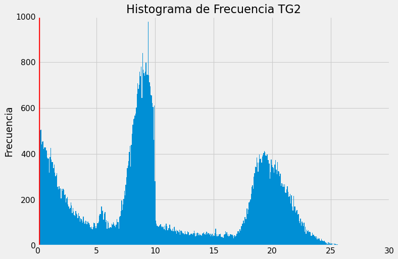

```python
TG2_MVA_median= Gene['TG2_MVA'].median()
TG2_MVA_median
plt.figure(figsize=(10,7), dpi= 80)
plt.hist(TG2['TG2_MVA'], bins=1000)
plt.gca().set(title='Histograma de Frecuencia TG2', ylabel='Frecuencia');
plt.xlim(0,30)
plt.ylim(0,1000)
plt.axvline(TG2_MVA_median, color='red')
```

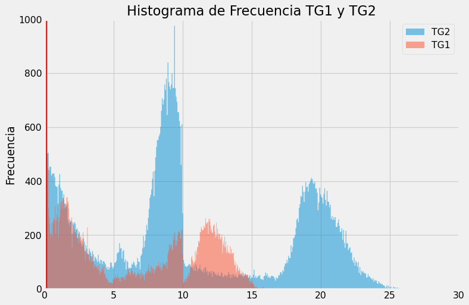

```python
TG2_MVA_median= Gene['TG2_MVA'].median()
TG2_MVA_median
plt.figure(figsize=(10,7), dpi= 80)
plt.hist(TG2['TG2_MVA'], histtype='stepfilled', alpha=0.5, bins=1000, label='TG2')
plt.hist(TG1['TG1_MVA'], histtype='stepfilled', alpha=0.5, bins=1000, label='TG1')
plt.gca().set(title='Histograma de Frecuencia TG1 y TG2', ylabel='Frecuencia');
plt.xlim(0,30)
plt.ylim(0,1000)
plt.axvline(TG2_MVA_median, color='red')
plt.legend()
```

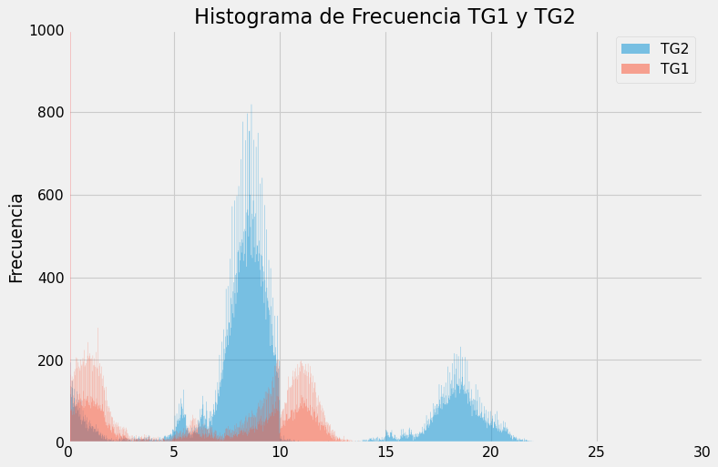

```python
TG2_MW_median= Gene['TG2_MW'].median()
TG2_MW_median
plt.figure(figsize=(10,7), dpi= 80)
plt.hist(TG2['TG2_MW'], histtype='stepfilled', alpha=0.5, bins=1000, label='TG2')
plt.hist(TG1['TG1_MW'], histtype='stepfilled', alpha=0.5, bins=1000, label='TG1')
plt.gca().set(title='Histograma de Frecuencia TG1 y TG2', ylabel='Frecuencia');
plt.xlim(0,30)
plt.ylim(0,1000)
plt.axvline(TG2_MW_median, color='red')
plt.legend()
```

```python
g18 = Gene[Gene['TG2_MVA'] == 18.0]
```

```python
g8 = TG2[TG2['TG2_MW'] == 8.00]
```

```python
Gene.info()
```

```
<class 'pandas.core.frame.DataFrame'>
DatetimeIndex: 736161 entries, 2011-01-01 00:15:00 to 2021-12-31 23:55:00
Data columns (total 7 columns):
 #   Column    Non-Null Count   Dtype
---  ------    --------------   -----
 0   TG1_MW    736161 non-null  float64
 1   TG1_MVAR  736161 non-null  float64
 2   TG1_MVA   736161 non-null  float64
 3   TG2_MW    736161 non-null  float64
 4   TG2_MVAR  736161 non-null  float64
 5   TG2_MVA   736161 non-null  float64
 6   Suma      736161 non-null  float64
dtypes: float64(7)
memory usage: 61.1 MB
```

```python
584785+47455
```

```
632240
```

```python
TG1_MW_genero = Gene[Gene['TG1_MW'] != 0.00]
```

```python
TG1_MW_genero.loc['2011':'2016']
```

| Fecha_Hora | TG1_MW | TG1_MVAR | TG1_MVA | TG2_MW | TG2_MVAR | TG2_MVA | Suma |
| --- | --- | --- | --- | --- | --- | --- | --- |
| 2011-01-01 00:15:00 | 11.22 | 2.39 | 11.47 | 0.00 | 0.06 | 0.06 | 11.53 |
| 2011-01-01 13:30:00 | 10.65 | 1.87 | 10.81 | 0.00 | 0.07 | 0.07 | 10.88 |
| 2011-01-01 13:45:00 | 10.63 | 1.31 | 10.71 | 0.00 | 0.07 | 0.07 | 10.78 |
| 2011-01-01 14:00:00 | 10.57 | 1.04 | 10.62 | 0.00 | 0.06 | 0.06 | 10.68 |
| 2011-01-01 14:15:00 | 10.42 | 1.04 | 10.47 | 0.00 | 0.08 | 0.08 | 10.55 |
| ... | ... | ... | ... | ... | ... | ... | ... |
| 2016-12-31 23:35:00 | 7.85 | 0.37 | 7.85 | 20.23 | 4.01 | 20.62 | 28.47 |
| 2016-12-31 23:40:00 | 7.86 | 0.38 | 7.87 | 20.13 | 4.03 | 20.53 | 28.40 |
| 2016-12-31 23:45:00 | 7.83 | 0.38 | 7.84 | 19.97 | 3.83 | 20.34 | 28.18 |
| 2016-12-31 23:50:00 | 7.79 | 0.38 | 7.80 | 19.96 | 3.71 | 20.30 | 28.10 |
| 2016-12-31 23:55:00 | 7.78 | 0.25 | 7.79 | 19.96 | 3.48 | 20.26 | 28.05 |

38927 rows × 7 columns

```python
TG1_MW_genero.loc['2017':'2021']
```

| Fecha_Hora | TG1_MW | TG1_MVAR | TG1_MVA | TG2_MW | TG2_MVAR | TG2_MVA | Suma |
| --- | --- | --- | --- | --- | --- | --- | --- |
| 2017-01-01 00:00:00 | 7.79 | 0.38 | 7.80 | 19.87 | 3.24 | 20.14 | 27.94 |
| 2017-01-01 00:05:00 | 7.81 | 0.39 | 7.82 | 19.87 | 3.08 | 20.11 | 27.93 |
| 2017-01-01 00:10:00 | 7.83 | 0.40 | 7.84 | 19.99 | 3.13 | 20.23 | 28.07 |
| 2017-01-01 00:15:00 | 7.80 | 0.40 | 7.81 | 19.96 | 3.01 | 20.18 | 27.99 |
| 2017-01-01 00:20:00 | 7.79 | 0.37 | 7.80 | 20.04 | 3.04 | 20.27 | 28.07 |
| ... | ... | ... | ... | ... | ... | ... | ... |
| 2021-12-30 21:50:00 | 8.72 | 1.76 | 8.89 | 7.51 | 1.99 | 7.62 | 16.51 |
| 2021-12-30 21:55:00 | 8.75 | 1.74 | 8.92 | 7.22 | 2.16 | 7.35 | 16.27 |
| 2021-12-30 22:00:00 | 8.75 | 1.79 | 8.93 | 7.45 | 1.57 | 7.52 | 16.45 |
| 2021-12-30 22:05:00 | 8.85 | 1.89 | 9.05 | 7.15 | 5.79 | 8.10 | 17.15 |
| 2021-12-30 22:10:00 | 3.11 | 0.84 | 3.22 | 7.39 | 6.38 | 8.53 | 11.75 |

10816 rows × 7 columns

```python
t1 = (38927*15)/60/24
t2 = (10816*5)/60/24
tt = t1 + t2
#print('TG1 genero [Dias] 2011-2016', t1 )
#print('TG1 genero [Dias] 2017-2020', t2)
print('TG1 genero : ', tt, ' dias')
print('TG1 genero : ', (tt//365), 'anios  y ', (tt%365), 'dias')
print('En 10 anios se uso :', tt/3650*100)
```

```
TG1 genero :  443.04513888888886  dias
TG1 genero :  1.0 anios  y  78.04513888888886 dias
En 10 anios se uso : 12.138222983257227
```

### CONCLUSION: Durante 10 anios TG1 se uso 443 dias (1 anio y 78 dias) o bien 12 % de uso

```python
TG2_MW_genero = TG2[TG2['TG2_MW'] != 0.00]
```

```python
TG2_MW_genero.loc['2011':'2016']
```

| Fecha_Hora | TG2_MW | TG2_MVAR | TG2_MVA |
| --- | --- | --- | --- |
| 2011-05-26 18:45:00 | 5.37 | 0.97 | 5.45 |
| 2011-05-26 19:00:00 | 0.85 | 1.19 | 0.92 |
| 2011-05-26 19:15:00 | 5.22 | -0.64 | 5.23 |
| 2011-05-29 17:00:00 | 5.32 | 1.70 | 5.58 |
| 2011-05-29 17:15:00 | 0.79 | 0.38 | 0.79 |
| ... | ... | ... | ... |
| 2016-12-31 23:35:00 | 20.23 | 4.01 | 20.62 |
| 2016-12-31 23:40:00 | 20.13 | 4.03 | 20.53 |
| 2016-12-31 23:45:00 | 19.97 | 3.83 | 20.34 |
| 2016-12-31 23:50:00 | 19.96 | 3.71 | 20.30 |
| 2016-12-31 23:55:00 | 19.96 | 3.48 | 20.26 |

64049 rows × 3 columns

```python
TG2_MW_genero.loc['2017':'2021']
```

| Fecha_Hora | TG2_MW | TG2_MVAR | TG2_MVA |
| --- | --- | --- | --- |
| 2017-01-01 00:00:00 | 19.87 | 3.24 | 20.14 |
| 2017-01-01 00:05:00 | 19.87 | 3.08 | 20.11 |
| 2017-01-01 00:10:00 | 19.99 | 3.13 | 20.23 |
| 2017-01-01 00:15:00 | 19.96 | 3.01 | 20.18 |
| 2017-01-01 00:20:00 | 20.04 | 3.04 | 20.27 |
| ... | ... | ... | ... |
| 2021-12-30 21:55:00 | 7.22 | 2.16 | 7.35 |
| 2021-12-30 22:00:00 | 7.45 | 1.57 | 7.52 |
| 2021-12-30 22:05:00 | 7.15 | 5.79 | 8.10 |
| 2021-12-30 22:10:00 | 7.39 | 6.38 | 8.53 |
| 2021-12-30 22:15:00 | 0.71 | 1.88 | 0.87 |

17840 rows × 3 columns

```python
t1 = (64049*15)/60/24
t2 = (17840*5)/60/24
tt = t1 + t2
#print('TG1 genero [Dias] 2011-2016', t1 )
#print('TG1 genero [Dias] 2017-2020', t2)
print('TG1 genero : ', tt, ' dias')
print('TG1 genero : ', (tt//365), 'anios  y ', (tt%365), 'dias')
print('En 10 anios se uso :', tt/3650*100)
```

```
TG1 genero :  729.1215277777778  dias
TG1 genero :  1.0 anios  y  364.1215277777778 dias
En 10 anios se uso : 19.975932267884325
```

### CONCLUSION: Durante 10 anios TG2 se uso 1 anio y 364 dias (casi 2 anios) 20 % de uso

## Grafica_xmin

```python
#
# Grafica Potencia Aparente x DIA

def Grafica_xmin(pi, pf):
    plt.style.use('fivethirtyeight')

    #y = datos.loc[anio:anio, 'MVA'].resample('D').max()
    #x = y.index

    gg = Gene.loc[pi:pf, ['TG1_MVA', 'TG2_MVA', 'Suma']]


    x = gg['TG1_MVA']
    y = gg['TG2_MVA']

    s = gg['Suma']
    t = x.index

    fig = plt.figure()
    fig, grafico = plt.subplots(figsize=(30, 5))

    #grafico.plot(x, y, lw=1, label='Potencia Aparente', marker='o')
    grafico.plot(t, x, lw=1, label='TG1', marker='o', color='g')
    grafico.plot(t, y, lw=1, label='TG2', marker='o', color='y')

    grafico.plot(t, s, lw=2, label='TG1+TG2', marker='o', color='k')

    grafico.set_xlabel('[ Meses ]')  # Add an x-label to the axes.
    grafico.set_ylabel('[ MVA ]')  # Add a y-label to the axes.
    grafico.set_title("POTENCIA APARENTE DIARIA " + pi + pf)  # Add a title to the axes.
    grafico.legend()  # Add a legend.
    #grafico.annotate('Pico Max', xy=(01-31 14:45, 75), xytext=(01-31 15:00, 75), arrowprops=dict(facecolor='black', shrink=0.05)
    #grafico.grid()

    #fig.savefig("Serie_Anual_Gene.loc[pi:pf, ['TG1_MVA', 'TG2_MVA', 'Suma']]xDia_"+anio+".png")
```

```python
Gene.loc['2019-01', ['TG1_MVA', 'TG2_MVA', 'Suma']]
```

| Fecha_Hora | TG1_MVA | TG2_MVA | Suma |
| --- | --- | --- | --- |
| 2019-01-01 00:00:00 | 0.08 | 0.08 | 0.16 |
| 2019-01-01 00:05:00 | 0.08 | 0.08 | 0.16 |
| 2019-01-01 00:10:00 | 0.08 | 0.08 | 0.16 |
| 2019-01-01 00:15:00 | 0.08 | 0.08 | 0.16 |
| 2019-01-01 00:20:00 | 0.08 | 0.08 | 0.16 |
| ... | ... | ... | ... |
| 2019-01-31 23:35:00 | 0.08 | 0.08 | 0.16 |
| 2019-01-31 23:40:00 | 0.07 | 0.08 | 0.15 |
| 2019-01-31 23:45:00 | 0.07 | 0.08 | 0.15 |
| 2019-01-31 23:50:00 | 0.08 | 0.08 | 0.16 |
| 2019-01-31 23:55:00 | 0.08 | 0.08 | 0.16 |

8885 rows × 3 columns

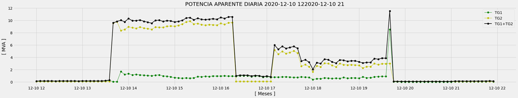

```python
Grafica_xmin('2020-12-10 12', '2020-12-10 21')
```

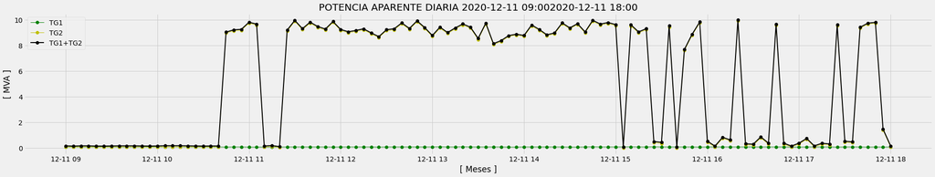

```python
Grafica_xmin('2020-12-11 09:00', '2020-12-11 18:00')
```

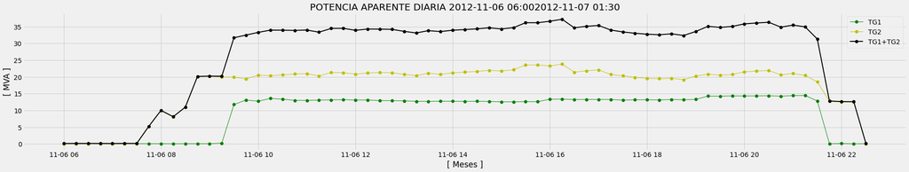

```python
Grafica_xmin('2012-11-06 06:00', '2012-11-07 01:30')  # ACA ESTAN FALTANDO DATOS ENTRE LAS 22:30 Y LAS 05:00
```

```python
Gene.loc['2012-11-06 22:00':'2012-11-07 05:30', :]
```

| Fecha_Hora | TG1_MW | TG1_MVAR | TG1_MVA | TG2_MW | TG2_MVAR | TG2_MVA | Suma |
| --- | --- | --- | --- | --- | --- | --- | --- |
| 2012-11-06 22:00:00 | 0.00 | -0.13 | 0.13 | 12.50 | -0.32 | 12.50 | 12.63 |
| 2012-11-06 22:15:00 | 0.00 | 0.03 | 0.03 | 12.54 | -0.68 | 12.56 | 12.59 |
| 2012-11-06 22:30:00 | 0.00 | 0.07 | 0.07 | 0.00 | 0.08 | 0.08 | 0.15 |
| 2012-11-07 05:00:00 | 0.00 | 0.06 | 0.06 | 0.00 | 0.06 | 0.06 | 0.12 |
| 2012-11-07 05:15:00 | 0.00 | 0.07 | 0.07 | 0.00 | 0.06 | 0.06 | 0.13 |
| 2012-11-07 05:30:00 | 0.00 | 0.07 | 0.07 | 0.00 | 0.07 | 0.07 | 0.14 |

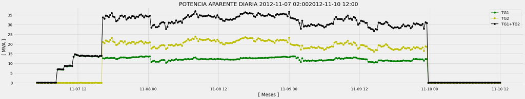

```python
Grafica_xmin('2012-11-07 02:00', '2012-11-10 12:00')
```

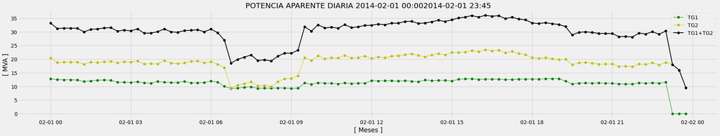

```python
Grafica_xmin('2014-02-01 00:00', '2014-02-01 23:45')
```

```python
Gene.loc['2012-11-09 23:00':'2012-11-10 01:00', :]
```

| Fecha_Hora | TG1_MW | TG1_MVAR | TG1_MVA | TG2_MW | TG2_MVAR | TG2_MVA | Suma |
| --- | --- | --- | --- | --- | --- | --- | --- |
| 2012-11-09 23:00:00 | 11.04 | 2.87 | 11.40 | 16.42 | -0.20 | 16.42 | 27.82 |
| 2012-11-09 23:15:00 | 12.19 | -1.82 | 12.33 | 18.56 | -3.30 | 18.85 | 31.18 |
| 2012-11-09 23:30:00 | 12.29 | 0.52 | 12.30 | 18.49 | 1.64 | 18.56 | 30.86 |
| 2012-11-09 23:45:00 | 0.00 | -0.01 | 0.01 | 0.00 | 0.07 | 0.07 | 0.08 |
| 2012-11-10 00:00:00 | 0.00 | 0.06 | 0.06 | 0.00 | 0.06 | 0.06 | 0.12 |
| 2012-11-10 00:15:00 | 0.00 | 0.08 | 0.08 | 0.00 | 0.07 | 0.07 | 0.15 |
| 2012-11-10 00:30:00 | 0.00 | 0.06 | 0.06 | 0.00 | 0.06 | 0.06 | 0.12 |
| 2012-11-10 00:45:00 | 0.00 | 0.06 | 0.06 | 0.00 | 0.06 | 0.06 | 0.12 |
| 2012-11-10 01:00:00 | 0.00 | 0.06 | 0.06 | 0.00 | 0.06 | 0.06 | 0.12 |

# Valores Maximos de Suma x Dia

```python
#
# Generar Pot_max_xdia para todos los anios

# Obtengo los Valores Maximos x Dia  ---- No puedo utilizar resample('D') porque me da los valores Maximos para todas las columnas
# y yo necesito los valores MVA para los cuales Suma es maxima en el Dia

Pot_max_xdia = pd.DataFrame(columns = ['TG1_MW', 'TG1_MVA', 'TG2_MW', 'TG2_MVA', 'Suma'])

#anios = ['2011', '2012', '2013', '2014', '2015', '2016', '2017', '2018', '2019', '2020']
anio_ini = '2011'
anio_fin = '2021'
pi = anio_ini + '-01-01'
pf = anio_fin + '-12-31'

dias = pd.date_range(start=pi, end=pf, freq='D')
for dia in dias:
    dia = dia.strftime('%Y/%m/%d')
    if Gene.loc[dia, :].empty :
        pass
    else:
        ind = Gene.loc[dia, 'Suma'].idxmax()
        Pot_max_xdia.loc[ind] = Gene.loc[ind, ['TG1_MW', 'TG1_MVA', 'TG2_MW', 'TG2_MVA', 'Suma']]

Pot_max_xdia
```

|  | TG1_MW | TG1_MVA | TG2_MW | TG2_MVA | Suma |
| --- | --- | --- | --- | --- | --- |
| 2011-01-01 22:15:00 | 11.66 | 12.88 | 0.00 | 0.06 | 12.94 |
| 2011-01-02 23:30:00 | 11.73 | 13.68 | 0.00 | 0.06 | 13.74 |
| 2011-01-03 09:30:00 | 10.80 | 12.65 | 0.00 | 0.07 | 12.72 |
| 2011-01-04 09:45:00 | 11.38 | 13.84 | 0.00 | 0.06 | 13.90 |
| 2011-01-05 22:45:00 | 12.51 | 15.02 | 0.00 | 0.07 | 15.09 |
| ... | ... | ... | ... | ... | ... |
| 2021-12-27 14:15:00 | 9.92 | 9.93 | 7.35 | 8.00 | 17.93 |
| 2021-12-28 13:00:00 | 8.26 | 8.43 | 7.49 | 7.76 | 16.19 |
| 2021-12-29 12:10:00 | 9.68 | 9.71 | 7.32 | 7.61 | 17.32 |
| 2021-12-30 20:30:00 | 8.71 | 8.85 | 7.61 | 9.05 | 17.90 |
| 2021-12-31 12:45:00 | 0.00 | 0.09 | 0.00 | 0.10 | 0.19 |

4017 rows × 5 columns

```python
Pot_max_xdia['2020-10-11']
```

|  | TG1_MW | TG1_MVA | TG2_MW | TG2_MVA | Suma |
| --- | --- | --- | --- | --- | --- |
| 2020-10-11 14:45:00 | 0.00 | 0.09 | 0.00 | 0.09 | 0.18 |

```python
Pot_max_xdia[(Pot_max_xdia['TG1_MW'] != 0.00) ]
```

|  | TG1_MW | TG1_MVA | TG2_MW | TG2_MVA | Suma |
| --- | --- | --- | --- | --- | --- |
| 2011-01-01 22:15:00 | 11.66 | 12.88 | 0.00 | 0.06 | 12.94 |
| 2011-01-02 23:30:00 | 11.73 | 13.68 | 0.00 | 0.06 | 13.74 |
| 2011-01-03 09:30:00 | 10.80 | 12.65 | 0.00 | 0.07 | 12.72 |
| 2011-01-04 09:45:00 | 11.38 | 13.84 | 0.00 | 0.06 | 13.90 |
| 2011-01-05 22:45:00 | 12.51 | 15.02 | 0.00 | 0.07 | 15.09 |
| ... | ... | ... | ... | ... | ... |
| 2021-12-23 14:15:00 | 9.37 | 9.38 | 7.59 | 8.15 | 17.53 |
| 2021-12-27 14:15:00 | 9.92 | 9.93 | 7.35 | 8.00 | 17.93 |
| 2021-12-28 13:00:00 | 8.26 | 8.43 | 7.49 | 7.76 | 16.19 |
| 2021-12-29 12:10:00 | 9.68 | 9.71 | 7.32 | 7.61 | 17.32 |
| 2021-12-30 20:30:00 | 8.71 | 8.85 | 7.61 | 9.05 | 17.90 |

1048 rows × 5 columns

```python
TG2_max = Pot_max_xdia[(Pot_max_xdia['TG2_MW'] != 0.00)]
```

```python
tg2 = TG2_max.loc['2011', : ]
```

## Verifico Dias que faltan en Pot_max_xdia

```python
# CHEQUEA EL INDICE POR DIAS FALTANTES
# SI FALTA UN DIA: AGREGA LA FILA CON VALORES NAN

pi = Pot_max_xdia.index[0]
pi = pi.strftime('%Y/%m/%d')
pf = Pot_max_xdia.index[-1]
pf = pf.strftime('%Y/%m/%d')

ind_ok = pd.date_range(start=pi, end=pf, freq="D")
ind_ck = Pot_max_xdia.index.date

dife = ind_ok.difference(ind_ck)

for ind in dife.values:
    Pot_max_xdia.loc[ind] = np.nan, np.nan, np.nan, np.nan, np.nan

Pot_max_xdia_nan = Pot_max_xdia.sort_index()
Pot_max_xdia_ori = Pot_max_xdia_nan.copy()

Pot_max_xdia_nan
```

|  | TG1_MW | TG1_MVA | TG2_MW | TG2_MVA | Suma |
| --- | --- | --- | --- | --- | --- |
| 2011-01-01 22:15:00 | 11.66 | 12.88 | 0.00 | 0.06 | 12.94 |
| 2011-01-02 23:30:00 | 11.73 | 13.68 | 0.00 | 0.06 | 13.74 |
| 2011-01-03 09:30:00 | 10.80 | 12.65 | 0.00 | 0.07 | 12.72 |
| 2011-01-04 09:45:00 | 11.38 | 13.84 | 0.00 | 0.06 | 13.90 |
| 2011-01-05 22:45:00 | 12.51 | 15.02 | 0.00 | 0.07 | 15.09 |
| ... | ... | ... | ... | ... | ... |
| 2021-12-27 14:15:00 | 9.92 | 9.93 | 7.35 | 8.00 | 17.93 |
| 2021-12-28 13:00:00 | 8.26 | 8.43 | 7.49 | 7.76 | 16.19 |
| 2021-12-29 12:10:00 | 9.68 | 9.71 | 7.32 | 7.61 | 17.32 |
| 2021-12-30 20:30:00 | 8.71 | 8.85 | 7.61 | 9.05 | 17.90 |
| 2021-12-31 12:45:00 | 0.00 | 0.09 | 0.00 | 0.10 | 0.19 |

4018 rows × 5 columns

```python
dife
```

```
DatetimeIndex(['2020-12-27'], dtype='datetime64[ns]', freq=None)
```

## Interpolacion de Pot_max_xdia

```python
#  INTERPOLAR LOS DIAS FALTANTES

Pot_max_xdia = Pot_max_xdia_nan.interpolate()
```

## Grafica_xDia

```python
# Grafica del Pico Maximo Potencia Aparente x DIA

def Grafica_xDia(pi, pf):
    plt.style.use('fivethirtyeight')

    #pi = anio + '-07-01'
    #pf = anio + '-07-31'

    x = Pot_max_xdia.loc[pi:pf, 'TG1_MVA']
    y = Pot_max_xdia.loc[pi:pf, 'TG2_MVA']

    s = Pot_max_xdia.loc[pi:pf, 'Suma']
    t = x.index

    fig = plt.figure()
    fig, grafico = plt.subplots(figsize=(30, 5))

    #grafico.plot(x, y, lw=1, label='Potencia Aparente', marker='o')
    grafico.plot(t, x, lw=1, label='TG1', marker='o', color='g')
    grafico.plot(t, y, lw=1, label='TG2', marker='o', color='y')

    grafico.plot(t, s, lw=2, label='TG1+TG2', marker='o', color='k')

    grafico.set_xlabel('[ Meses ]')  # Add an x-label to the axes.
    grafico.set_ylabel('[ MVA ]')  # Add a y-label to the axes.
    grafico.set_title("POTENCIA APARENTE DIARIA " + pi + pf)  # Add a title to the axes.
    grafico.legend()  # Add a legend.
    #grafico.annotate('Pico Max', xy=(01-31 14:45, 75), xytext=(01-31 15:00, 75), arrowprops=dict(facecolor='black', shrink=0.05)
    #grafico.grid()

    #fig.savefig("Serie_Anual_xDia_"+anio+".png")
```

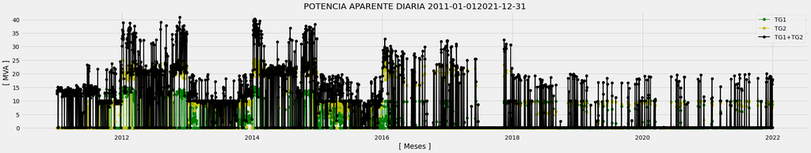

```python
Grafica_xDia('2011-01-01', '2021-12-31') # PARA TODOS LOS ANIOS
```

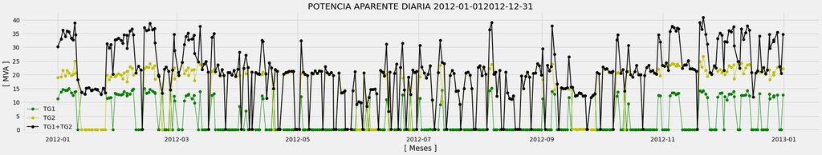

```python
Grafica_xDia('2012-01-01', '2012-12-31') # PARA EL ANIO 2012
```

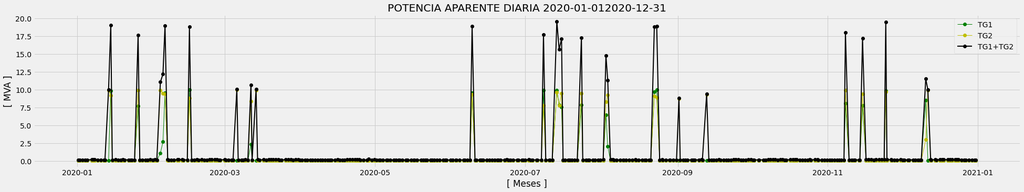

```python
Grafica_xDia('2020-01-01', '2020-12-31') # PARA EL ANIO 2020
```

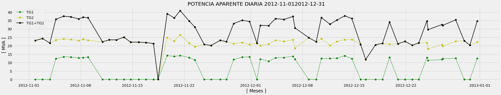

```python
Grafica_xDia('2012-11-01', '2012-12-31')
```

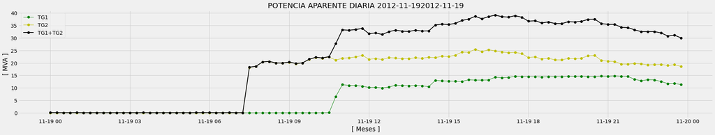

```python
Grafica_xmin('2012-11-19', '2012-11-19')
```

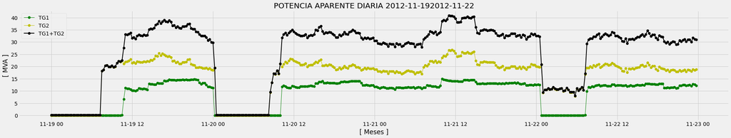

```python
Grafica_xmin('2012-11-19', '2012-11-22')
```

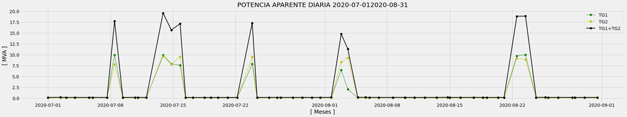

```python
Grafica_xDia('2020-07-01', '2020-08-31')
```

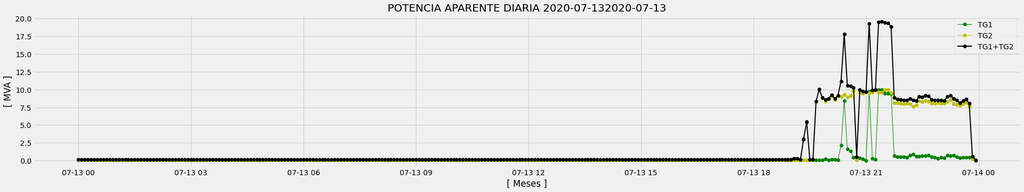

```python
Grafica_xmin('2020-07-13', '2020-07-13')
```

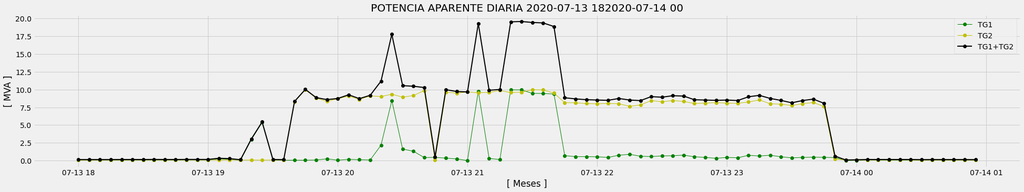

```python
Grafica_xmin('2020-07-13 18', '2020-07-14 00')
```

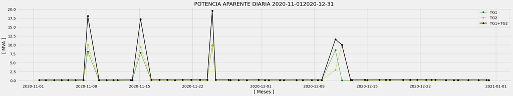

```python
Grafica_xDia('2020-11-01', '2020-12-31')
```

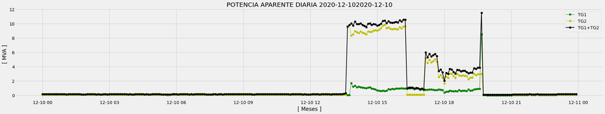

```python
Grafica_xmin('2020-12-10', '2020-12-10')
```

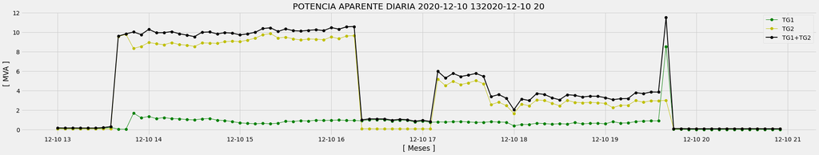

```python
Grafica_xmin('2020-12-10 13', '2020-12-10 20')
```

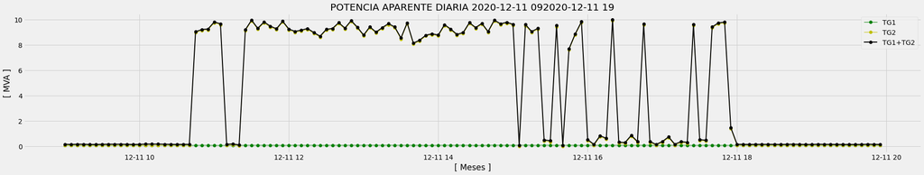

```python
Grafica_xmin('2020-12-11 09', '2020-12-11 19')
```

# Valores Maximos de Suma x Mes

No tiene mucho sentido en Generadores pero puede servir para ver si estuvo Parada o en Mantenimiento

```python
#
# Generar Pot_Max_xMes para todos los anios

# Obtengo los Valores Maximos x MES  ---- No puedo utilizar resample('D') porque me da los valores Maximos para todas las columnas
# y yo necesito los valores MVA para los cuales Suma es maxima en el MES

#anios = ['2011', '2012', '2013', '2014', '2015', '2016', '2017', '2018', '2019', '2020']

Pot_max_xmes = pd.DataFrame(columns = ['TG1_MVA', 'TG2_MVA', 'Suma'])

anio_ini = '2011'
anio_fin = '2020'
pi = anio_ini + '-01-01'
pf = anio_fin + '-12-31'

meses = pd.date_range(start=pi, end=pf, freq='M')
for mes in meses:
    mes = mes.strftime('%Y/%m')
    if Gene.loc[mes, :].empty :
        pass
    else:
        ind = Gene.loc[mes, 'Suma'].idxmax()
        Pot_max_xmes.loc[ind] = Gene.loc[ind, ['TG1_MVA', 'TG2_MVA', 'Suma']]

Pot_max_xmes.tail()
```

|  | TG1_MVA | TG2_MVA | Suma |
| --- | --- | --- | --- |
| 2020-08-23 11:35:00 | 9.98 | 8.90 | 18.88 |
| 2020-09-12 18:35:00 | 0.07 | 9.37 | 9.44 |
| 2020-10-07 17:35:00 | 0.09 | 0.11 | 0.20 |
| 2020-11-24 13:55:00 | 9.85 | 9.68 | 19.53 |
| 2020-12-10 19:40:00 | 8.51 | 3.01 | 11.52 |

## Grafica_xMes

```python
# Grafica del Pico Maximo Potencia Aparente x DIA

def Grafica_xMes(pi, pf):
    plt.style.use('fivethirtyeight')

    TG1 = Pot_max_xmes.loc[pi:pf, 'TG1_MVA']
    TG2 = Pot_max_xmes.loc[pi:pf, 'TG2_MVA']

    Suma = Pot_max_xmes.loc[pi:pf, 'Suma']
    tiempo = TG1.index

    fig = plt.figure()
    fig, grafico = plt.subplots(figsize=(30, 5))

    #grafico.plot(x, y, lw=1, label='Potencia Aparente', marker='o')
    grafico.plot(tiempo, TG1, lw=1, label='TD1', marker='o', color='g')
    grafico.plot(tiempo, TG2, lw=1, label='TD2', marker='o', color='y')

    grafico.plot(tiempo, Suma, lw=2, label='TG1+TG2', marker='o', color='k')

    grafico.set_xlabel('[ Meses ]')  # Add an x-label to the axes.
    grafico.set_ylabel('[ MVA ]')  # Add a y-label to the axes.
    grafico.set_title("POTENCIA APARENTE DIARIA " + pi + pf)  # Add a title to the axes.
    grafico.legend()  # Add a legend.
    #grafico.annotate('Pico Max', xy=(01-31 14:45, 75), xytext=(01-31 15:00, 75), arrowprops=dict(facecolor='black', shrink=0.05)
    #grafico.grid()

    #fig.savefig("Serie_Anual_xDia_"+anio+".png")
```

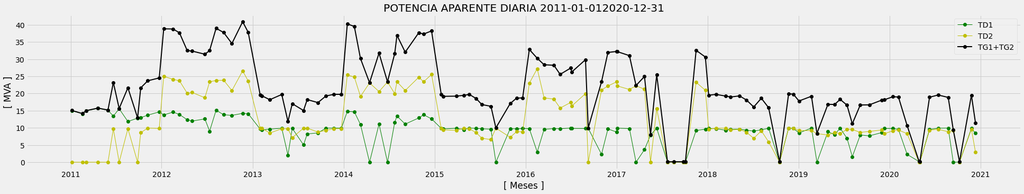

```python
Grafica_xMes('2011-01-01','2020-12-31')
```

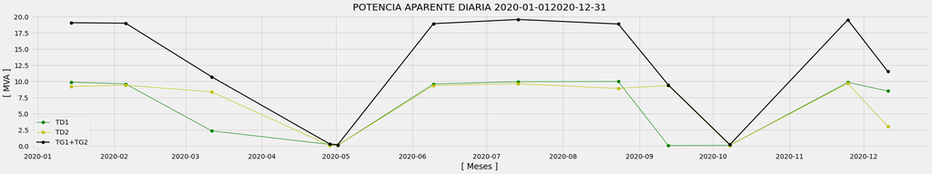

```python
Grafica_xMes('2020-01-01','2020-12-31')
```

# borradores

## Chequeo si hay Registros / Filas Faltantes

Si dife distinto de cero, significa que faltan registros/filas en los datos del SITEC

```python
#pot5 = Pot_max_xdia.reindex(indice)
```

```python
parar_corrida
pot2.index.format()
pot2.index.values
#pot2.index.is_all_dates()
if pot2.index.has_duplicates:
    print('SI TIENE DUPLI')
else:
    print('NO tiene')
```

[output not shown]

```python
Pot_max_xmes.head()
```

```python
if dife.empty == False:
    print('Faltan algunas Mediciones: ', len(dife), '% Incompletas= ', (len(dife)/len(indice)*100), '% Completas= ', \
          (((len(indice)-len(dife))/len(indice))*100))
else:
    print('Mediciones Completas: ', (((len(indice)-len(dife))/len(indice))*100))
```

```python
#datos2 = datos.drop(['Fecha', 'Hora'], axis=1)
#data.drop(['Fecha', 'Hora', 'Ampere', 'KVolt'], axis=1)
#datos2.iloc[0:100, :]
```

```python
TD1_atipicos
```

```python
#plt.boxplot(Trafos['TD1_MVA', 'TD2_MVA', 'TD3_MVA', 'Suma'])

data = TD1[['TD1_MVA']]
fig1, ax1 = plt.subplots()
ax1.set_title('TD1 Potencia Aparente")')
#plt.ylabel("TD1_MVA")
ax1.set_ylabel('TD1_MVA', fontsize=15)  # Add a y-label to the axes.
ax1.set_ylim([0,80])
ax1.boxplot(data)
plt.show()
```

```python
# Deteccion de Outliers

# BORRAMOS LOS ATIPICOS DEL TRAFO TD1

# if TD1_atipicos.empty == False:
#     indice = TD1_atipicos.index
#     TD1 = TD1.drop(indice)
#     print('Atipicos identificados: %d' % len(TD1_atipicos))
# else:
#     print('SIN Atipicos para borrar: %d' % len(TD1_atipicos))
```

```python
# CONCATENAR TD1 + TD2 + TD3
#
tr = pd.concat([TD1_sin_atipicos, TD2_sin_atipicos, TD3_sin_atipicos], axis = 1)
tr
```

```python
TD1_sin_atipicos.loc['2017-01', :]
```

```python
TD2_sin_atipicos.loc['2017-01-04', : ]
```

```python
TD3_sin_atipicos.loc['2017-01-04', : ]
```

```python
tr.loc['2017-01-27 09:25:00':'2017-01-27 09:30:00', :]
```

```python
tr.loc['2017-01-27 09:20:00':'2017-01-27 09:35:00', :]
```

```python
TD3_atipicos
```

```python
TD3_sin_atipicos.loc['2017-02-04 02:10:00':'2017-02-04 02:15:00', :]
```

```python
dia = '2014-03-18'
TD1.loc[dia, :]
```

```python
dia = '2014-03-18'
TD1.loc['2020-12-26 23':'2020-12-28 12', :]
```

```python
Trafos
```

```python
# CHEQUEA EL INDICE POR DIAS FALTANTES
# SI FALTA UN DIA: AGREGA LA FILA CON VALORES NAN

ind_td1 = TD1_sin_atipicos.index
ind_td2 = TD2_sin_atipicos.index

dife = ind_td2.difference(ind_td1)
dife
```

```python
len(dife)
```

```python
ind_td1_2017 = TD1_sin_atipicos.loc['2017':'2020', :].index
ind_td3 = TD3_sin_atipicos.index

dife2 = ind_td3.difference(ind_td1_2017)
dife2
```

```python
145+53
```

```python
TD1_sin_atipicos.loc['2017':'2020', :]
```

```python
dife3 = dife.difference(ind_td3)
dife3
```

```python
len(dife3)
```

```python
Trafos.loc['2017-01-20 06:30:00':'2017-01-20 14:25:00' , :]
```

```python
Trafos.loc['2017-01-20 11:00:00':'2017-01-20 11:55:00' , :]
```

```python
TD3.loc['2017-01-20 06:30:00':'2017-01-20 14:25:00' , :]
```

```python
ind1 = TD1_sin_atipicos.loc['2017':'2020', :].index
```